# Salifort Motors - ML Modelling - Logistic Regression

### Confusion Matrix Heatmap LR1

```python
# Prepare confusion matrices for LR1 test
cm_test = metrics.confusion_matrix(y_test, y_pred_test)  # Use the optimized model
cm_test_percent = cm_test / cm_test.sum() * 100

# Prepare confusion matrices for LR1 train
cm_train = metrics.confusion_matrix(y_train, y_pred_train)  # Use the optimized model
cm_train_percent = cm_train / cm_train.sum() * 100

print("Test")
print(cm_test )
print(cm_test_percent)
print("\n Train")
print(cm_train)
print(cm_train_percent)
```

```
Test
[[2164  157]
 [ 370  101]]
[[77.50716332  5.62320917]
 [13.252149    3.61747851]]

 Train
[[6537  427]
 [1139  272]]
[[78.05373134  5.09850746]
 [13.6         3.24776119]]
```

```
<function matplotlib.pyplot.show(close=None, block=None)>
```

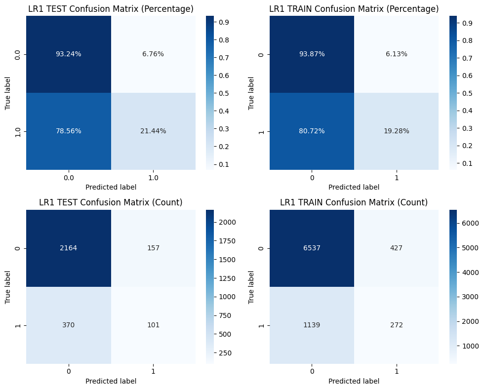

```python
fig, ax = plt.subplots(2, 2, figsize=(10,8))


ax[0,0].set_title("test")

sum_by_true_class = np.sum(cm_test, axis=1)
percentage_matrix = cm_test / sum_by_true_class[:, np.newaxis]

# Create a figure and plot the percentage confusion matrix as a heatmap

sns.heatmap(percentage_matrix, annot=True, fmt=".2%", cmap="Blues", ax = ax[0,0], xticklabels=model_lr1.classes_, yticklabels=model_lr1.classes_)
ax[0,0].set_title('LR1 TEST Confusion Matrix (Percentage)')
ax[0,0].set_ylabel('True label')
ax[0,0].set_xlabel('Predicted label')


sum_by_true_class = np.sum(cm_train, axis=1)
percentage_matrix = cm_train / sum_by_true_class[:, np.newaxis]

sns.heatmap(percentage_matrix, annot=True, fmt=".2%", cmap="Blues", ax = ax[0,1])#, xticklabels=class_labels, yticklabels=class_labels)
ax[0,1].set_title('LR1 TRAIN Confusion Matrix (Percentage)')
ax[0,1].set_ylabel('True label')
ax[0,1].set_xlabel('Predicted label')

# Create a figure and plot the percentage confusion matrix as a heatmap
sns.heatmap(cm_test, annot=True, fmt=".0f", cmap="Blues", ax = ax[1,0])#, xticklabels=class_labels, yticklabels=class_labels)
ax[1,0].set_title('LR1 TEST Confusion Matrix (Count)')
ax[1,0].set_ylabel('True label')
ax[1,0].set_xlabel('Predicted label')


sum_by_true_class = np.sum(cm_test, axis=1)
percentage_matrix = cm_test / sum_by_true_class[:, np.newaxis]

sns.heatmap(cm_train, annot=True, fmt=".0f", cmap="Blues", ax = ax[1,1])#, xticklabels=class_labels, yticklabels=class_labels)
ax[1,1].set_title('LR1 TRAIN Confusion Matrix (Count)')
ax[1,1].set_ylabel('True label')
ax[1,1].set_xlabel('Predicted label')

plt.tight_layout()
plt.show
```

### Feature Importance

```python
feature_importance = model_lr1.coef_[0]  # In binary classification, it's lr.coef_[0]

# Sort features by importance
sorted_indices = feature_importance.argsort()[::-1]
sorted_feature_names = [X.columns[i] for i in sorted_indices]
sorted_importance = feature_importance[sorted_indices]

# Print feature importance
for feature, importance in zip(sorted_feature_names, sorted_importance):
    print(f"{feature:20}: {importance:.4f}")
```

```
tenure              : 0.9967
last_eval           : 0.1086
dept_technical      : 0.0343
dept_sales          : 0.0317
dept_support        : 0.0207
dept_hr             : 0.0175
dept_product_mng    : -0.0010
dept_it             : -0.0060
dept_marketing      : -0.0100
dept_management     : -0.0282
dept_accounting     : -0.0530
dept_randd          : -0.0759
promotion           : -0.2083
overworked          : -0.3133
salary              : -0.3226
number_project      : -0.3982
satisfaction        : -1.0231
```

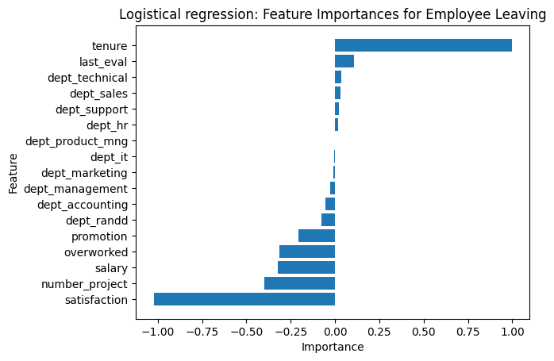

```python
plt.barh(sorted_feature_names, sorted_importance)
plt.title("Logistical regression: Feature Importances for Employee Leaving", fontsize=12)
plt.ylabel("Feature")
plt.xlabel("Importance")
plt.gca().invert_yaxis()
plt.show()
```

# Construct Model - Logistical Regression 2

This is the model that will exclude the departments

### Import data - `model_lr2`

Two datasets for model performance comparison, :

- `data_cleaned_NoOl_FE_AllFeat.csv` is the full data set feature engineered with `salary` encoded to ordinal, `avg_mth_hrs` binary encoded to `overwork` and dept encoded with dummies
- `data_cleaned_NoOl_FE_NoDept.csv` is the same data with the dummy encoded dept fields removed.

`Dept` appears to have low correlation across the dataset and I'm curious how much the models are influenced with low correlation features. It turns out that low correlation features have little impact on model performance. which is no surprise really!

#### Code flags:

**rerun** = flag to identify the first run of the model comparisons and write a NEW Results.csv file. 0 = first run and a new file will be created with headers / 1 = Continuation, Results will be appended to the file.

**dataset** = Text indicating which dataset is being used, added to the model description during csv save to Results.csv

**model_prefix** = text indicating which ML model is being used, added to the model description during csv save to Results.csv

```python
df2 = pd.read_csv(load_path + "data_cleaned_NoOl_FE_NoDept.csv", index_col = False) # Feature engineering on salary, avg_mnth_hrs, outliers removed, departments removed

# prefix for results.csv added to dataset
model_prefix         = 'lr2'

# dataset name for results.csv
dataset              = 'NOdept'

# 1 = append to the Results.csv file with no headers / 0 = Write new file with headers
rerun                = 1

print("df2 - Feature engineering on salary, avg_mnth_hrs, dept REMOVED, outliers removed\n")
# Display dataframe columns
print(df2.info())
```

```
df2 - Feature engineering on salary, avg_mnth_hrs, dept REMOVED, outliers removed

<class 'pandas.core.frame.DataFrame'>
RangeIndex: 11167 entries, 0 to 11166
Data columns (total 8 columns):
 #   Column          Non-Null Count  Dtype
---  ------          --------------  -----
 0   satisfaction    11167 non-null  float64
 1   last_eval       11167 non-null  float64
 2   number_project  11167 non-null  float64
 3   overworked      11167 non-null  int64
 4   tenure          11167 non-null  float64
 5   left            11167 non-null  float64
 6   promotion       11167 non-null  float64
 7   salary          11167 non-null  int64
dtypes: float64(6), int64(2)
memory usage: 698.1 KB
None
```

### Prepare data for modelling - `model_lr2`

```python
model_data2 = df2.copy() # copy df to df used for modelling
```

### Isolate Outcome and Feature Variables - `model_lr2`

```python
# Linear Regression model

# Save X and Y data into variables
Y2 = model_data2['left'] # Isolate the outcome variable
X2 = model_data2.copy()
X2 = X2.drop('left', axis = 1) # Isolate the feature variables, drop the outcome variable left
#X = sm.add_constant(X)
```

### Test Train split data - `model_lr2`

```python
# Split Test/Train Data
X_train2, X_test2, y_train2, y_test2 = train_test_split(X2,Y2, test_size=0.25, stratify=Y, random_state=42)
```

### Apply StandardScalar to feature variables - `model_lr2`

Standardize features by removing the mean and scaling to unit variance. Generally only required for regression models.

```python
scaler = StandardScaler()
X_train2 = scaler.fit_transform(X_train2)
X_test2 = scaler.transform(X_test2)
```

### Instantiate Model - `model_lr2`

```python
# Fit the multiple regression model
model_lr2 = LogisticRegression() # Training Data
```

### Fit Data for `model_lr2` - Train data

```python
model_lr2.fit(X_train2, y_train2) # Training data for model_lr1
```

```
LogisticRegression()
```

### Make Predictions - `model_lr2` - Test data

```python
# Make Predictions using Logistic Regression
y_pred_test2 = model_lr2.predict(X_test2)
```

### Classification Report - `model_lr2` - Test data

```python
classification_report_summary(model_prefix+' - '+dataset+' - '+'TEST', y_test2, y_pred_test2)
```

```
Classification Report :  lr2 - NOdept - TEST
                           precision    recall  f1-score   support

Predicted would not leave       0.85      0.93      0.89      2321
    Predicted would leave       0.36      0.19      0.25       471

                 accuracy                           0.81      2792
                macro avg       0.60      0.56      0.57      2792
             weighted avg       0.77      0.81      0.78      2792

Recall        : 0.19
f1_score      : 0.25
Precision     : 0.36
Accuracy      : 0.81

-----------------------------------------------------------------------
Weighted Average
-----------------------------------------------------------------------
Recall        : 0.81
f1 Score      : 0.78
Precision     : 0.77
Support       : 2792.00

-----------------------------------------------------------------------
Prediction F1 score
-----------------------------------------------------------------------
Predict Leave : 0.25
Support Stay  : 0.89
```

### Prepare and Save Results - `model_lr2` - Test data

```python
result_table = make_lr_results(model_prefix+' - '+dataset+' - '+'test',model_lr2, X_test2, y_test2, y_pred_test2)

# If the model is being run for the first time, create a new Results.csv file
if rerun == 0:

    # First save to Results.csv, no mode set, write headers, write new file
    result_table.to_csv("Results.csv", index=True, header=True)

# If the model is being RERUN with a new data, APPEND to existing Results.csv
elif rerun == 1 :

    # APPEND save to Results.csv, don't write headers, APPEND new file
    result_table.to_csv("Results.csv", index=True, mode='a', header=False)
```